# Case study 2

Xiangshi Li

8/14/2019

```r
knitr::opts_chunk$set(warning=FALSE)
```

# Part 0: Reviews of Case study 1 and Abstract

### Reviews

"Are there a lot of variables with missing data (i.e., some variables with NA values?) - not NAs from the tidying process, but instead NAs that were already in the raw data (e.g., missing values for price?). If yes, please report it as a **data quality issue**.

Great start at tidying the data! Although what you have done is excellent, you still have some work left to **have a tidy dataset (e.g., sellers).** Can you please work on that and finish the tidying of the data for CS2?

Another thing is, while you have done a great job at cleaning, **the sellers variable is still not super clean.** Using **stringr and regular** expression to clean up some of the special characters will help. I would like for you to work on that as well.

Finally, I know there are tons of cool things you want to do for CS2 (e.g., find relationships between products) but my advice is to really **focus on tidying the data** so that more meaningful analyses can be done. When we meet tomorrow for class, I will talk more in details what exactly I am looking for, and some of the steps you can take to get there. This is not to say you shouldn’t do these things (if you can, do them all!), but is just to emphasize the priority for the analyses. "

# Part 1: Data quality and data cleaning

After importing the data into Rstudio, we can find that there are 10000 observations and 17 variables in the data set.However, by checking the names of products, I can find that some of the products have same names.

```r
same<-select(amazon,product_name)
same<-same%>%
  group_by(product_name)%>%
  summarise(count=n())
same<-arrange(same,desc(count))
head(same,5)
```

```
## # A tibble: 5 x 2
##   product_name                                                        count
##   <chr>                                                               <int>
## 1 Polyhedral Dice                                                         3
## 2 Zoo Animal Hand Sock Glove Finger Puppets Sack Plush Toy Cow            3
## 3 100 six sided dice, 14mm, random colours                                2
## 4 20Q                                                                     2
## 5 22 Silicone Reborn Baby Girl Realistic Newborn Baby Doll for Toddl~     2
```

I needed to check the data quality, that is how many missing values are in different variables. Here I wrote a loop to calculate the number of missing values.

```r
nanumber<-data.frame(colnames(amazon))
nacount<-c()
for (x in colnames(amazon)){
  nacount[[x]]=sum(is.na(amazon[[x]]))
}
nanumber$nacount<-nacount
nanumber
```

```
##                               colnames.amazon. nacount
## 1                                      uniq_id       0
## 2                                 product_name       0
## 3                                 manufacturer       6
## 4                                        price    1435
## 5                    number_available_in_stock    2500
## 6                            number_of_reviews      20
## 7                 number_of_answered_questions     765
## 8                        average_review_rating      18
## 9             amazon_category_and_sub_category     690
## 10  customers_who_bought_this_item_also_bought    1062
## 11                                 description     650
## 12                         product_information      58
## 13                         product_description     650
## 14 items_customers_buy_after_viewing_this_item    3065
## 15              customer_questions_and_answers    9086
## 16                            customer_reviews      21
## 17                                     sellers    3082
```

This is the summary of NA values in different variables. Nearly all variables have NAs. While some variables such as “manufacturer” and “average_review_rating” have a few NAs, other variables such as “customer_questions_and_answers” have a huge amount of NAs. Although 14 % of the data are NAs for the whole data set, which is OK for the following analyses, the data quality of different variables varies a lot.

Next I tidied the data set for analyses. I can find the some values in certain variables, such as **price** , have the sign before the number. Meanwhile, the **ratings** of product are in the string format, which I need to transfer into number before making calculations. There are many data showed in a format that is hard to operate. I did the following steps to tidy the data and create a new data set for the following analyse.

```r
amazon_product<-select(amazon,uniq_id:price,number_of_reviews,number_of_answered_questions,average_review_rating,description,product_information,product_description,cat_final)
head(amazon_product)
```

```
## # A tibble: 6 x 11
##   uniq_id product_name manufacturer price number_of_revie~ number_of_answe~
##   <chr>   <chr>        <chr>        <dbl>            <dbl>            <dbl>
## 1 eac7ef~ Hornby 2014~ Hornby        3.42               15                1
## 2 b17540~ FunkyBuysB. ~ FunkyBuys    17.0                 2                1
## 3 348f34~ CLASSIC TOY~ ccf           9.99               17                2
## 4 e12b92~ HORNBY Coac~ Hornby       40.0                 1                2
## 5 e33a9a~ Hornby 00 G~ Hornby       32.2                 3                2
## 6 cb34f0~ 20pcs Model~ Generic       6.99                2                1
## # ... with 5 more variables: average_review_rating <dbl>,
## #   description <chr>, product_information <chr>,
## #   product_description <chr>, cat_final <chr>
```

Metadata:

- Uniq_id: [chr] The id of toys on amazon.
- Product_name: [chr] The name of toys on amazon
- manufacturer: [chr] The item manufacturer, as reported on Amazon.
- price: [num] The price of different toys in dollar.
- number_of_reviews: [num] The number of reviews in each toy.
- number_of_answered_questions: [num] The count of how many questions are asked and answered.
- average_review_rating: [num] The average rating score of a toy.
- description: [chr] The introduction of the toy.
- product_information: [chr] Some detail information about the toy.
- product_description: [chr] The same as description.
- cat_final: [chr] The categories that I defined as the final.

```r
amazon_stock<-select(amazon,uniq_id:manufacturer,number_of_stock,condition)
head(amazon_stock)
```

```
## # A tibble: 6 x 5
##   uniq_id      product_name          manufacturer number_of_stock condition
##   <chr>        <chr>                 <chr>                  <dbl> <chr>
## 1 eac7efa5dbd~ Hornby 2014 Catalogue Hornby                     5 new
## 2 b17540ef7e8~ FunkyBuysB. Large Chr~ FunkyBuys                 NA <NA>
## 3 348f344247b~ CLASSIC TOY TRAIN SE~ ccf                        2 new
## 4 e12b92dbb8e~ HORNBY Coach R4410A ~ Hornby                    NA <NA>
## 5 e33a9adeed5~ Hornby 00 Gauge 0-4-~ Hornby                    NA <NA>
## 6 cb34f0a8410~ 20pcs Model Garden L~ Generic                   NA <NA>
```

Except the variables mentioned above, metadata about new variables are as followed:

- number_of_stock: [num] Number of available stocks.
- condition: [chr] The condition of the stock product. Whether is new, used or other conditions.

```r
amazon_category<-select(amazon,uniq_id:manufacturer,cat1:cat5,cat_final)
head(amazon_category)
```

```
## # A tibble: 6 x 9
##   uniq_id product_name manufacturer cat1  cat2  cat3  cat4  cat5  cat_final
##   <chr>   <chr>        <chr>        <chr> <chr> <chr> <chr> <chr> <chr>
## 1 eac7ef~ Hornby 2014~ Hornby       Hobb~ Mode~ Rail~ Trai~ <NA>  Trains
## 2 b17540~ FunkyBuysB. ~ FunkyBuys    Hobb~ Mode~ Rail~ Trai~ <NA>  Trains
## 3 348f34~ CLASSIC TOY~ ccf          Hobb~ Mode~ Rail~ Trai~ <NA>  Trains
## 4 e12b92~ HORNBY Coac~ Hornby       Hobb~ Mode~ Rail~ Trai~ <NA>  Trains
## 5 e33a9a~ Hornby 00 G~ Hornby       Hobb~ Mode~ Rail~ Trai~ <NA>  Trains
## 6 cb34f0~ 20pcs Model~ Generic      Hobb~ Mode~ Ligh~ Lamp~ <NA>  Lamps & ~
```

metadata about new variables are as followed:

- cat1-cat5: [chr] The different levels of categories for a product. Some products have information about 5 sub-categories while some have just 1.
- cat_final: [chr] The categories that I defined as the final.

```r
amazon_alsobought<-select(amazon,uniq_id:manufacturer,cat_final,also_bought_1:also_bought_12,also_bought_num)
head(amazon_alsobought)
```

```
## # A tibble: 6 x 17
##   uniq_id product_name manufacturer cat_final also_bought_1 also_bought_2
##   <chr>   <chr>        <chr>        <chr>     <chr>         <chr>
## 1 eac7ef~ Hornby 2014~ Hornby       Trains    http://www.a~ http://www.a~
## 2 b17540~ FunkyBuysB. ~ FunkyBuys    Trains    http://www.a~ http://www.a~
## 3 348f34~ CLASSIC TOY~ ccf          Trains    http://www.a~ http://www.a~
## 4 e12b92~ HORNBY Coac~ Hornby       Trains    <NA>          <NA>
## 5 e33a9a~ Hornby 00 G~ Hornby       Trains    http://www.a~ http://www.a~
## 6 cb34f0~ 20pcs Model~ Generic      Lamps & ~ http://www.a~ http://www.a~
## # ... with 11 more variables: also_bought_3 <chr>, also_bought_4 <chr>,
## #   also_bought_5 <chr>, also_bought_6 <chr>, also_bought_7 <chr>,
## #   also_bought_8 <chr>, also_bought_9 <chr>, also_bought_10 <chr>,
## #   also_bought_11 <chr>, also_bought_12 <chr>, also_bought_num <dbl>
```

```r
amazon_also_gather<-gather(amazon_alsobought,also_bought_1:also_bought_12,key="alsoid",value="also_bought")
amazon_also_gather<-filter(amazon_also_gather,!is.na(also_bought))
amazon_also_gather<-select(amazon_also_gather,uniq_id,also_bought)
```

metadata about new variables are as followed:

- also_bought_1 - also_bought_12: [chr] The links of also-bought products for a given toy. Some toys have up to 12 also-bought products.
- also_bought_num: [num] The number of also-bought toys for a given toy.

```r
amazon_buyafterview<-select(amazon,uniq_id:manufacturer,cat_final,buy_after_view1:buy_after_view4,buy_after_view_num)
head(amazon_buyafterview)
```

```
## # A tibble: 6 x 9
##   uniq_id product_name manufacturer cat_final buy_after_view1
##   <chr>   <chr>        <chr>        <chr>     <chr>
## 1 eac7ef~ Hornby 2014~ Hornby       Trains    http://www.ama~
## 2 b17540~ FunkyBuysB. ~ FunkyBuys    Trains    http://www.ama~
## 3 348f34~ CLASSIC TOY~ ccf          Trains    http://www.ama~
## 4 e12b92~ HORNBY Coac~ Hornby       Trains    <NA>
## 5 e33a9a~ Hornby 00 G~ Hornby       Trains    http://www.ama~
## 6 cb34f0~ 20pcs Model~ Generic      Lamps & ~ http://www.ama~
## # ... with 4 more variables: buy_after_view2 <chr>, buy_after_view3 <chr>,
## #   buy_after_view4 <chr>, buy_after_view_num <dbl>
```

```r
amazon_bav_gather<-gather(amazon_buyafterview,buy_after_view1:buy_after_view4,key="buyid",value="buy_after_view")
amazon_bav_gather<-filter(amazon_bav_gather,!is.na(buy_after_view))
amazon_bav_gather<-select(amazon_bav_gather,uniq_id,buy_after_view)
```

metadata about new variables are as followed:

- buy_after_view1 - buy_after_view4: [chr] The links of buy-after-view products for a given toy. Some toys have up to 4 buy-after-view products.(buy-after-view products: items that customers buy after viewing this item)
- buy_after_view_num: [num] The number of buy_after_view toys for a given toy.

```r
amazon_QA<-select(amazon,uniq_id:manufacturer,Q1:A10)
head(amazon_QA)
```

```
## # A tibble: 6 x 23
##   uniq_id product_name manufacturer Q1    A1    Q2    A2    Q3    A3
##   <chr>   <chr>        <chr>        <chr> <chr> <chr> <chr> <chr> <chr>
## 1 eac7ef~ Hornby 2014~ Hornby       Does~ "HiT~ <NA>  <NA>  <NA>  <NA>
## 2 b17540~ FunkyBuysB. ~ FunkyBuys    can ~ hi n~ <NA>  <NA>  <NA>  <NA>
## 3 348f34~ CLASSIC TOY~ ccf          What~ Hi P~ what~ Its ~ <NA>  <NA>
## 4 e12b92~ HORNBY Coac~ Hornby       <NA>  <NA>  <NA>  <NA>  <NA>  <NA>
## 5 e33a9a~ Hornby 00 G~ Hornby       <NA>  <NA>  <NA>  <NA>  <NA>  <NA>
## 6 cb34f0~ 20pcs Model~ Generic      is i~ "Hi ~ <NA>  <NA>  <NA>  <NA>
## # ... with 14 more variables: Q4 <chr>, A4 <chr>, Q5 <chr>, A5 <chr>,
## #   Q6 <chr>, A6 <chr>, Q7 <chr>, A7 <chr>, Q8 <chr>, A8 <chr>, Q9 <chr>,
## #   A9 <chr>, Q10 <chr>, A10 <chr>
```

```r
q<-c("Q1","Q2","Q3","Q4","Q5","Q6","Q7","Q8","Q9","Q10")
a<-c("A1","A2","A3","A4","A5","A6","A7","A8","A9","A10")

amazon_q_gather<-gather(amazon_QA,q,key="qid",value="question")
amazon_q_gather<-filter(amazon_q_gather,!is.na(question))
amazon_q_gather<-select(amazon_q_gather,uniq_id,question)

amazon_a_gather<-gather(amazon_QA,a,key="aid",value="answer")
amazon_a_gather<-filter(amazon_a_gather,!is.na(answer))
amazon_a_gather<-select(amazon_a_gather,uniq_id,answer)
```

metadata about new variables are as followed:

- Q1 - Q10: [chr] The questions asked about a product.
- A1 - A10: [chr] The answers provided for the questions about the product.

```r
amazon_review<-select(amazon,uniq_id:manufacturer,average_review_rating,review1short_review:review8long_review)
head(amazon_review)
```

```
## # A tibble: 6 x 44
##   uniq_id product_name manufacturer average_review_~ review1short_re~
##   <chr>   <chr>        <chr>                   <dbl> <chr>
## 1 eac7ef~ Hornby 2014~ Hornby                    4.9 Worth Buying Fo~
## 2 b17540~ FunkyBuysB. ~ FunkyBuys                 4.5 Four Stars
## 3 348f34~ CLASSIC TOY~ ccf                       3.9 **Highly Recomm~
## 4 e12b92~ HORNBY Coac~ Hornby                    5   I love it
## 5 e33a9a~ Hornby 00 G~ Hornby                    4.7 Birthday present
## 6 cb34f0~ 20pcs Model~ Generic                   5   Five Stars
## # ... with 39 more variables: review1rate <dbl>, review1date <date>,
## #   review1cus_name <chr>, review1long_review <chr>,
## #   review2short_review <chr>, review2rate <dbl>, review2date <date>,
## #   review2cus_name <chr>, review2long_review <chr>,
## #   review3short_review <chr>, review3rate <dbl>, review3date <date>,
## #   review3cus_name <chr>, review3long_review <chr>,
## #   review4short_review <chr>, review4rate <dbl>, review4date <date>,
## #   review4cus_name <chr>, review4long_review <chr>,
## #   review5short_review <chr>, review5rate <dbl>, review5date <date>,
## #   review5cus_name <chr>, review5long_review <chr>,
## #   review6short_review <chr>, review6rate <dbl>, review6date <date>,
## #   review6cus_name <chr>, review6long_review <chr>,
## #   review7short_review <chr>, review7rate <dbl>, review7date <date>,
## #   review7cus_name <chr>, review7long_review <chr>,
## #   review8short_review <chr>, review8rate <dbl>, review8date <date>,
## #   review8cus_name <chr>, review8long_review <chr>
```

```r
amazon_longreview<-select(amazon,uniq_id,ends_with("long_review"))
amazon_longreview<-gather(amazon_longreview,"review1long_review","review2long_review","review3long_review","review4long_review","review5long_review","review6long_review","review7long_review","review8long_review",key="id",value="review")
amazon_longreview<-filter(amazon_longreview,!is.na(review))

amazon_shortreview<-select(amazon,uniq_id,ends_with("short_review"))
amazon_shortreview<-gather(amazon_shortreview,"review1short_review","review2short_review","review3short_review","review4short_review","review5short_review","review6short_review","review7short_review","review8short_review",key="id",value="review")
amazon_shortreview<-filter(amazon_shortreview,!is.na(review))

amazon_datereview<-select(amazon,uniq_id,ends_with("date"))
amazon_datereview<-gather(amazon_datereview,"review1date","review2date","review3date","review4date","review5date","review6date","review7date","review8date",key="id",value="date")
amazon_datereview<-filter(amazon_datereview,!is.na(date))

amazon_cus_name<-select(amazon,uniq_id,ends_with("cus_name"))
amazon_cus_name<-gather(amazon_cus_name,"review1cus_name","review2cus_name","review3cus_name","review4cus_name","review5cus_name","review6cus_name","review7cus_name","review8cus_name",key="id",value="name")
amazon_cus_name<-filter(amazon_cus_name,!is.na(name))

amazon_ratereview<-select(amazon,uniq_id,ends_with("rate"))
amazon_ratereview<-gather(amazon_ratereview,"review1rate","review2rate","review3rate","review4rate","review5rate","review6rate","review7rate","review8rate",key="id",value="rate")
amazon_ratereview<-filter(amazon_ratereview,!is.na(rate))
```

metadata about new variables are as followed:

- review1short_review - review8short_review: [chr] The short review of a toy, usually a summary.
- review1rate - review8rate: [num] The rating score of a review.
- review1date - review8date: [date] The date when the review was given.
- review1cus_name - review8cus_name: [chr] The name of the customer who gave the review.
- review1long_review - review8long_review: [chr] The long review of a toy from the customer.

```r
amazon_seller<-select(amazon,uniq_id:manufacturer,cat_final,seller1name:seller20price,sell_num)
head(amazon_seller)
```

```
## # A tibble: 6 x 45
##   uniq_id product_name manufacturer cat_final seller1name seller1price
##   <chr>   <chr>        <chr>        <chr>     <chr>              <dbl>
## 1 eac7ef~ Hornby 2014~ Hornby       Trains    Amazon.co.~         3.42
## 2 b17540~ FunkyBuysB. ~ FunkyBuys    Trains    UHD WHOLES~        17.0
## 3 348f34~ CLASSIC TOY~ ccf          Trains    DEAL-BOX            9.99
## 4 e12b92~ HORNBY Coac~ Hornby       Trains    <NA>               NA
## 5 e33a9a~ Hornby 00 G~ Hornby       Trains    <NA>               NA
## 6 cb34f0~ 20pcs Model~ Generic      Lamps & ~ STK e-Shop          6.99
## # ... with 39 more variables: seller2name <chr>, seller2price <dbl>,
## #   seller3name <chr>, seller3price <dbl>, seller4name <chr>,
## #   seller4price <dbl>, seller5name <chr>, seller5price <dbl>,
## #   seller6name <chr>, seller6price <dbl>, seller7name <chr>,
## #   seller7price <dbl>, seller8name <chr>, seller8price <dbl>,
## #   seller9name <chr>, seller9price <dbl>, seller10name <chr>,
## #   seller10price <dbl>, seller11name <chr>, seller11price <dbl>,
## #   seller12name <chr>, seller12price <dbl>, seller13name <chr>,
## #   seller13price <dbl>, seller14name <chr>, seller14price <dbl>,
## #   seller15name <chr>, seller15price <dbl>, seller16name <chr>,
## #   seller16price <dbl>, seller17name <chr>, seller17price <dbl>,
## #   seller18name <chr>, seller18price <dbl>, seller19name <chr>,
## #   seller19price <dbl>, seller20name <chr>, seller20price <dbl>,
## #   sell_num <dbl>
```

metadata about new variables are as followed:

- seller1name - seller20name: [chr] The name of the seller who sell this toy on amazon.
- seller1price - seller20price: [num] The price of the toys from different seller .
- sell_num: [num] The number of sellers for a given product.

There are so many variables in data set amazon_seller! In order to make it more easy to look, I gathered the variables about seller and created a new data set about sellers.

```r
try<-amazon_seller

try<-gather(try,"seller1name","seller2name","seller3name","seller4name",
                "seller5name","seller6name","seller7name","seller8name",
                "seller9name","seller10name","seller11name","seller12name",
                "seller13name","seller14name","seller15name","seller16name",
                "seller17name","seller18name","seller19name","seller20name",key="sellerid",value="sellername")
try1<-amazon_seller
try1<-gather(try1,"seller1price","seller2price","seller3price","seller4price",
            "seller5price","seller6price","seller7price","seller8price",
            "seller9price","seller10price","seller11price","seller12price",
            "seller13price","seller14price","seller15price","seller16price",
            "seller17price","seller18price","seller19price","seller20price",key="sellerid",value="sellerprice")

try<-select(try,uniq_id,product_name,sellername)
try$sellerprice<-try1$sellerprice
amazon_seller_final<-filter(try,!is.na(sellername))
head(amazon_seller_final)
```

```
## # A tibble: 6 x 4
##   uniq_id         product_name                     sellername   sellerprice
##   <chr>           <chr>                            <chr>              <dbl>
## 1 eac7efa5dbd3d6~ Hornby 2014 Catalogue            Amazon.co.uk        3.42
## 2 b17540ef7e86e4~ FunkyBuysB. Large Christmas Holi~ UHD WHOLESA~       17.0
## 3 348f344247b0c1~ CLASSIC TOY TRAIN SET TRACK CAR~ DEAL-BOX            9.99
## 4 cb34f0a84102c1~ 20pcs Model Garden Light Double~ STK e-Shop          6.99
## 5 f74b562470571d~ Hornby 00 Gauge 230mm BR Bogie ~ MyHobbyStor~       25.0
## 6 87bbb472ef9d90~ Hornby Santa's Express Train Set Toy Arena          69.9
```

metadata about new variables are as followed:

- sellername: [chr] The name of the seller who sell this toy on amazon.
- sellerprice: [num] The price of the toys from different seller .

Now I’m ready to do the analyse work!

## Part 2: Competition for different manufacturer

While looking at the data set, the first question raised for me is about manufacturers. Which manufacturer is taking the lead in this industry? Let’s take a look at the data about manufacturers:

```r
head(unique(amazon_product),5)
```

```
## # A tibble: 5 x 11
##   uniq_id product_name manufacturer price number_of_revie~ number_of_answe~
##   <chr>   <chr>        <chr>        <dbl>            <dbl>            <dbl>
## 1 eac7ef~ Hornby 2014~ Hornby        3.42               15                1
## 2 b17540~ FunkyBuysB. ~ FunkyBuys    17.0                 2                1
## 3 348f34~ CLASSIC TOY~ ccf           9.99               17                2
## 4 e12b92~ HORNBY Coac~ Hornby       40.0                 1                2
## 5 e33a9a~ Hornby 00 G~ Hornby       32.2                 3                2
## # ... with 5 more variables: average_review_rating <dbl>,
## #   description <chr>, product_information <chr>,
## #   product_description <chr>, cat_final <chr>
```

```r
print(paste("number of manufacturer:",length(unique(amazon_product$manufacturer))))
```

```
## [1] "number of manufacturer: 2653"
```

From the summary I found that 2653 manufacturers are included in this data set. To understand which manufacturer is the most dominant, I needed to find some standards to measure the dominance. In this case study, I assumed that **number of sold products, number of reviews and number of sellers** can indicate the dominance.

I take a look at the numbers of products, number of reviews, the number of seller from each manufacturer.Comparing with case study 1, this time I filled the chart with the color of 2019: Living Coral!

```r
data_manu<-amazon_product%>%
  group_by(manufacturer)%>%
  summarize(count=n(),number_of_reviews=sum(number_of_reviews,na.rm=T))

manu1<-data_manu%>%
  arrange(desc(count))%>%
  head(8)%>%
  ggplot(aes(x=reorder(manufacturer,count),y=count))+
  geom_bar(stat="identity",fill="#FC766A",alpha=0.7)+
  ggtitle("Number of products for different manufacturers")+
  ylab("Number of products")+
  xlab("Manufacturers")+
  theme(plot.title = element_text(lineheight=.8, face="bold")) +
  theme_classic()+
  coord_flip()
```

```r
data_manu<-arrange(data_manu,desc(number_of_reviews))
manu2<-ggplot(head(data_manu,8),aes(x=reorder(manufacturer,number_of_reviews),y=number_of_reviews))+
  geom_bar(stat="identity",fill="#FC766A",alpha=0.7)+
  coord_flip()+
  ggtitle("Number of total reviews for different manufacturers")+
  ylab("Number of total reviews")+
  xlab("Manufacturers")+
  theme(plot.title = element_text(lineheight=.8, face="bold")) +
  theme_classic()
```

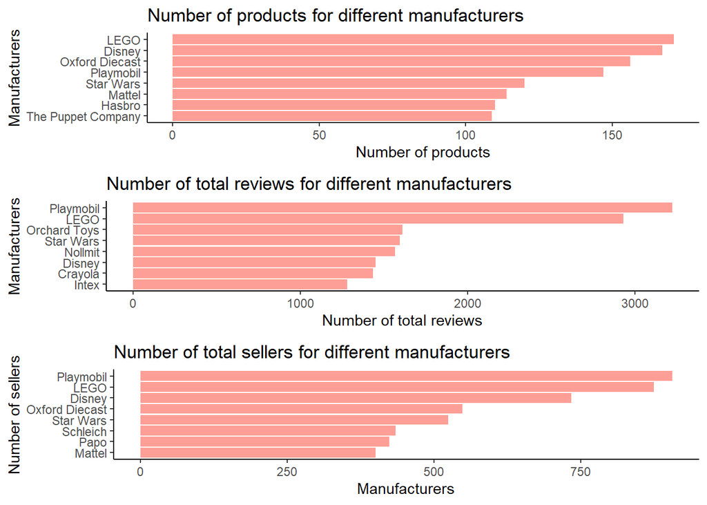

```r
data_sell<-amazon_seller%>%
  group_by(manufacturer)%>%
  summarize(sell_num=sum(sell_num,na.rm=T))%>%
  arrange(desc(sell_num))
manu3<-ggplot(head(data_sell,8),aes(x=reorder(manufacturer,sell_num),y=sell_num))+
  geom_bar(stat="identity",fill="#FC766A",alpha=0.7)+
  ggtitle("Number of total sellers for different manufacturers")+
  ylab("Manufacturers")+
  xlab("Number of sellers")+
  theme(plot.title = element_text(lineheight=.8, face="bold")) +
  theme_classic()+
  coord_flip()

ggarrange(manu1, manu2, manu3, ncol = 1, nrow = 3)
```

The number of product shows how many toys they have on the amazon. To figure out the manufacturers with dominance, I just showed the top 8 results. Manufacturer with more products are more likely to occupy more market share. The plot shows that **LEGO, Disney and Oxford Diecast** are the top 3 manufacturers that sell most toys on amazon, indicating their dominance in the toy industry.

The bar chart shows the top 8 manufacturer that receives the most reviews. From the chart I found that **Playmobil and LEGO** are the top 2. They get more reviews than others, indicating that they may have a larger sales volume and a better place in the market.

The bar chart show that **Playmobil, LEGO, Disney** also has a good performance on the seller market, which means that these brands are also the top choices for sellers. This can indicate the dominance of these brands.

If I combined the 3 variables together to do the analyses, I could get a better understand on which manufacturer has better performance in general. Here I drew a radar plot to compare performance. Because the ggplot doesn’t have radar plot function, I **wrote a function** to tidy the data for radar plot.

```r
data_manu<-arrange(data_manu,desc(manufacturer))
data_sell<-arrange(data_sell,desc(manufacturer))
radarmanu<-data_manu
radarmanu$sellernum<-data_sell$sell_num
radarmanu<-filter(radarmanu,count>50,sellernum>300)

radarplot<-function(dataframe,sep){
  for (x in sep){
    dataframe[[x]]<-dataframe[[x]]/max(dataframe[[x]])
  }

  dataframe<-dataframe%>%
    gather(sep,key="attrs",value="number")
}
sep<-c("count","number_of_reviews","sellernum")
radarmanu<-radarplot(radarmanu,sep)
```

There are so many manufacturers so I filtered the data to choose manufacturers with more than 50 products and 300 sellers to make the visualization easier to interpret. Here is the code to draw to radar plot.

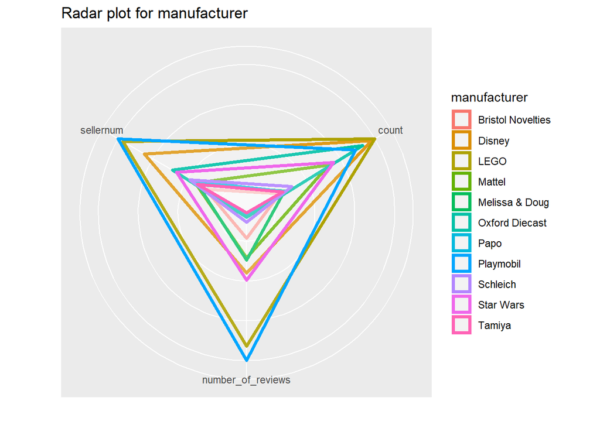

```r
ggplot(radarmanu,aes(x=attrs,y=number))+
  geom_polygon(aes(group = manufacturer,color=manufacturer),fill="white", alpha=0.1,size = 1.3)+
  theme(axis.ticks.y = element_blank(),
          axis.text.y = element_blank()) +
  xlab("") + ylab("") +
  ggtitle("Radar plot for manufacturer")+
  coord_polar()
```

From the radar plot I found that **LEGO** and **Playmobil** have good performances in 3 variables and have larger areas comparing with other manufacturers. They have outstanding data in seller numbers, number of products and total number of reviews. So I concluded that **LEGO** and **Playmobil** are playing dominant roles on the market.

## Part 3: Preference on different category

Another question for me is that which kind of toys is more popular? There are many ways to category products. Amazon use a category and sub_category method. As I mentioned in the data cleaning process, I used the last level of the raw data as the category.

```r
amazon_category<-amazon_category%>%
  filter(!is.na(cat_final))
head(unique(amazon_category$cat_final,5))
```

```
## [1] "Trains"                  "Lamps & Lighting"
## [3] "Locomotives"             "Signal & Sound"
## [5] "Recreational Activities" "Transformers & Decoders"
```

```r
print(paste("number of categories:",length(unique(amazon_category$cat_final))))
```

```
## [1] "number of categories: 235"
```

I divided all the products into 235 categories. After that, I needed to define what indicates popularity. In this case, I used **the number of products** and **number of reviews** to show the popularity, assuming that more products means customer’s choice and popularity and that larger number of review means more comments and concerns from customers.

```r
data_cat<-amazon_product%>%
  group_by(cat_final)%>%
  summarize(count=n(),number_of_reviews=sum(number_of_reviews,na.rm=T))
data_cat<-filter(data_cat,!cat_final=="")
```

```r
data_cat<-arrange(data_cat,desc(count))
cat1<-ggplot(head(data_cat,15),aes(x=reorder(cat_final,count),y=count))+
  geom_bar(stat="identity",fill="#FC766A",alpha=0.7)+
  ggtitle("Number of products for different categories")+
  ylab("Number of products")+
  xlab("Categories")+
  theme(plot.title = element_text(lineheight=.8, face="bold")) +
  theme_classic()+
  coord_flip()
```

```r
data_cat<-arrange(data_cat,desc(number_of_reviews))
cat2<-ggplot(head(data_cat,15),aes(x=reorder(cat_final,number_of_reviews),y=number_of_reviews))+
  geom_bar(stat="identity",fill="#FC766A",alpha=0.7)+
  ggtitle("Number of reviews for different categories")+
  ylab("Number of total reviews")+
  xlab("Categories")+
  theme(plot.title = element_text(lineheight=.8, face="bold")) +
  theme_classic()+
  coord_flip()
```

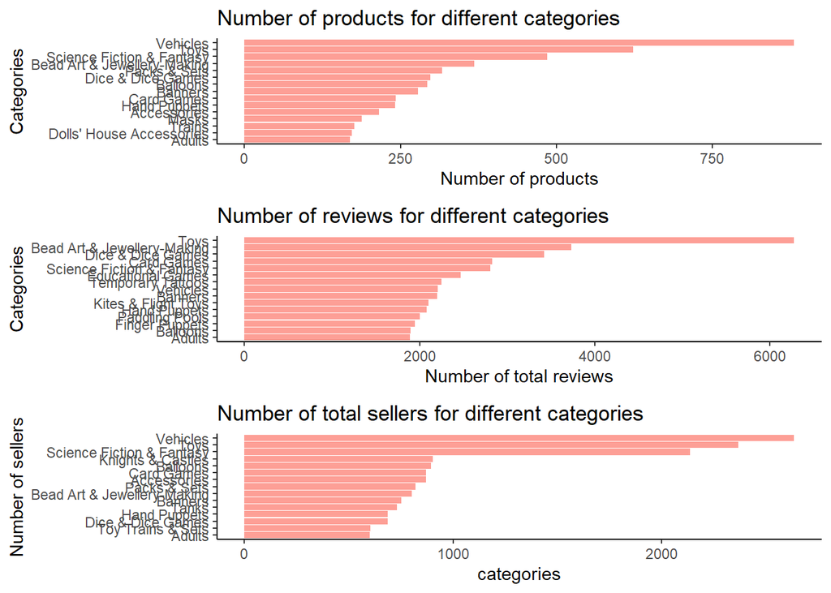

```r
data_sell<-amazon_seller%>%
  group_by(cat_final)%>%
  summarize(sell_num=sum(sell_num,na.rm=T))%>%
  arrange(desc(sell_num))
data_sell<-filter(data_sell,!is.na(cat_final))
cat3<-ggplot(head(data_sell,15),aes(x=reorder(cat_final,sell_num),y=sell_num))+
  geom_bar(stat="identity",fill="#FC766A",alpha=0.7)+
  ggtitle("Number of total sellers for different categories")+
  ylab("categories")+
  xlab("Number of sellers")+
  theme(plot.title = element_text(lineheight=.8, face="bold")) +
  theme_classic()+
  coord_flip()
ggarrange(cat1, cat2, cat3, ncol = 1, nrow = 3)
```

The plot shows that **Vehicles, Science Fiction& Fantasy and Bead Art & Jewelry-Making** has the most number of products.

The plot shows that **Bead Art & Jewellery-Making, Dice&Dice Games and Card Games**has the most reviews(“Toy” category is so ambiguous for analyse that I don’t count it.). This somehow shows the popularity.

The plot shows that toys in **vehicles and science fiction & fantasy** have more sellers, indicating that they have more popularity on the market.

This time I drew a radar plot to see the performance of different categories in different variables. Before drawing the plot I just kept the categories with more than 200 products and 500 sellers, and I dropped **Toys** category because it’s so ambiguous for analyse.

```r
data_cat<-arrange(data_cat,desc(cat_final))
data_sell<-arrange(data_sell,desc(cat_final))
radarcat<-data_cat
radarcat$sellernum<-data_sell$sell_num
radarcat<-filter(radarcat,count>200,sellernum>500)
radarcat<-filter(radarcat,cat_final!="Toys")
sep<-c("count","number_of_reviews","sellernum")
radarcat<-radarplot(radarcat,sep)
```

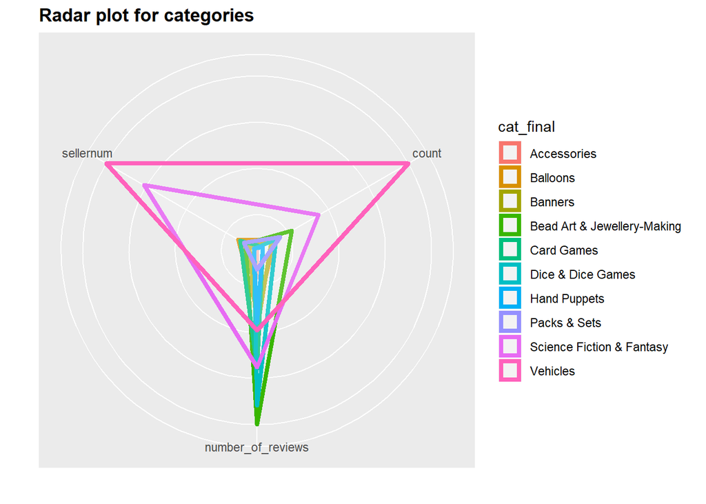

```r
ggplot(radarcat,aes(x=attrs,y=number))+
  geom_polygon(aes(group = cat_final,  color = cat_final),fill="white", alpha=0.1,size = 1.5)+
  theme(axis.ticks.y = element_blank(),
          axis.text.y = element_blank()) +
  xlab("") + ylab("") +
  ggtitle("Radar plot for categories")+
  theme(plot.title = element_text(lineheight=.8, face="bold")) +
  coord_polar()
```

It’s hard to say which category has better performance on 3 variables. By comparing the area of different category I concluded in general that toys in **Vehicles** and **Science Fiction & Fantasy** is more popular.

## Part 4: price of different manufacturer and category

```r
data_price1<-amazon_product%>%
  group_by(manufacturer)%>%
  summarize(count=n())
data_price1<-head(arrange(data_price1,desc(count)),8)
data_price1<-filter(amazon_product,manufacturer %in% as.vector(data_price1$manufacturer))
price1<-ggplot(data_price1,aes(x=manufacturer,y=price))+
  geom_hline(yintercept = 20,col="#FC766A",size=1.5)+
  geom_violin(draw_quantiles=c(0.25,0.5,0.75),scale="width")+
  xlab("Manufacturer")+
  ylab("Price")+
  ggtitle("Price distributions of toys in different manufacturers")+
  coord_flip()+
  theme_classic()
```

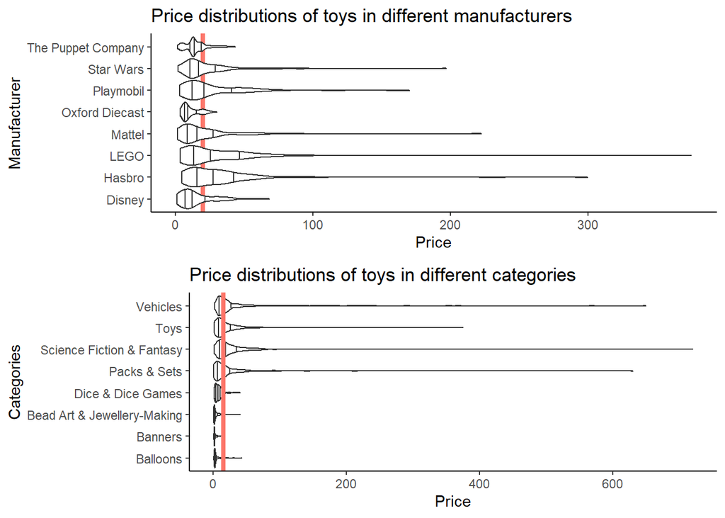

```r
data_price2<-amazon_product%>%
  group_by(cat_final)%>%
  summarize(count=n())
data_price2<-filter(data_price2,!is.na(cat_final))
data_price2<-head(arrange(data_price2,desc(count)),8)
data_price2<-filter(amazon_product,cat_final %in% as.vector(data_price2$cat_final))
price2<-ggplot(data_price2,aes(x=cat_final,y=price))+
  geom_violin(draw_quantiles=c(0.25,0.5,0.75),scale="width")+
  geom_hline(yintercept = 15,col="#FC766A",size=1.5)+
  ggtitle("Price distributions of toys in different categories")+
  xlab("Categories")+
  ylab("Price")+
  coord_flip()+
  theme_classic()

ggarrange(price1, price2,ncol = 1, nrow = 2)
```

## Part5: Products with the most influence

The data set contains information about items that also bought when customers purchased a products. This is a recommendation engine component that played a big role in making Amazon popular initially. It also has data about items that customers view after buying a product. This can somehow show the relationship among different products.

For the also-bought products, I first drew plots on the distribution of the number of also-bought products.

```r
a1<-ggplot(amazon_alsobought,aes(x=factor(also_bought_num)))+
  geom_bar(fill="#FC766A",alpha=0.7)+
  ggtitle("Distributions of also-bought products")+
  xlab("number of also-bought products")+
  ylab("count")+
  theme(plot.title = element_text(lineheight=.8, face="bold")) +
  theme_classic()
```

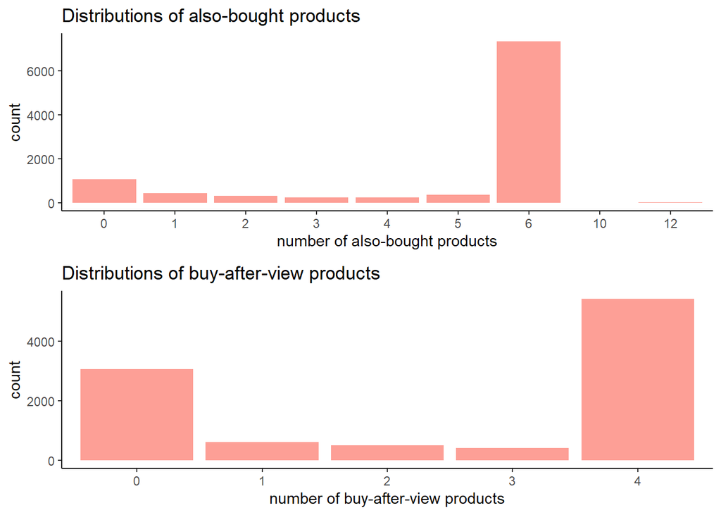

```r
b1<-ggplot(amazon_buyafterview,aes(x=factor(buy_after_view_num)))+
  geom_bar(fill="#FC766A",alpha=0.7)+
  ggtitle("Distributions of buy-after-view products")+
  xlab("number of buy-after-view products")+
  ylab("count")+
  theme(plot.title = element_text(lineheight=.8, face="bold")) +
  theme_classic()
ggarrange(a1,b1,nrow=2,ncol=1)
```

The Plot shows that most of the products have 6 also-bought products, indicating that more than 70% of the toys are bought with 6 other toys.

## part6: Predict the best review

In this part I concerned about how to predict the information of reviews of different products. I used **rate** to show the satisfaction from customers and assumed that the better rates, the better reviews.

First of all I took a look on the distribution of the average reviews rating. I drew a bar chart to show the result.

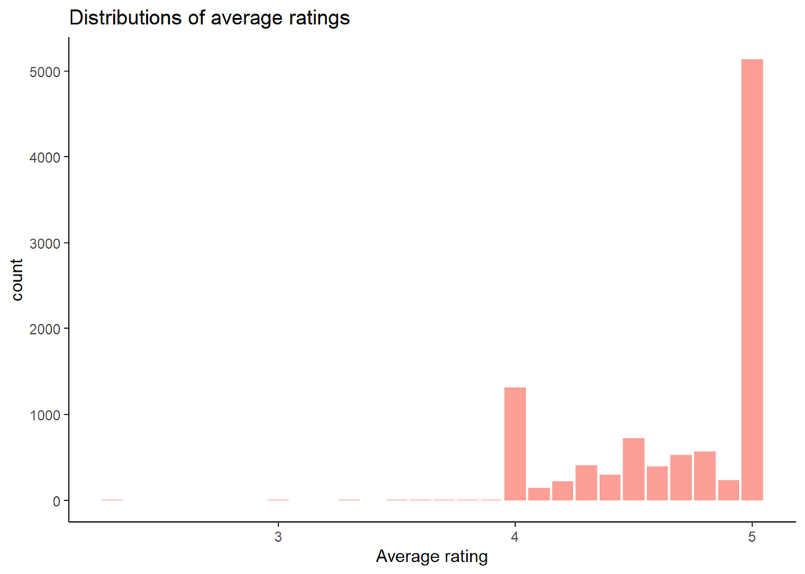

```r
ggplot(amazon_product,aes(x=average_review_rating))+
  geom_bar(fill="#FC766A",alpha=0.7)+
  ggtitle("Distributions of average ratings")+
  xlab("Average rating")+
  ylab("count")+
  theme(plot.title = element_text(lineheight=.8, face="bold")) +
  theme_classic()
```

More than half of the toys have a average rating of 5. Now I wanted to find factors that influence the average review rating.

I decided to see whether toys in certain manufacturers and categories may more likely to have higher average rates. I drew a plot to show the distribution of rates for different manufacturers. I just kept manufacturers and categories with more than 30 products because these manufacturers can provide adequate evidence.

```r
data_predict<-amazon_product%>%
  group_by(manufacturer)%>%
  summarize(count=n(),average_review_rating=mean(average_review_rating,na.rm=TRUE))
data_predict<-filter(data_predict,count>=30,!is.na(manufacturer))
data_predict<-arrange(data_predict,desc(average_review_rating))
data_predict<-head(data_predict,10)
data_predict<-arrange(filter(amazon_product,manufacturer %in% as.vector(data_predict$manufacturer)),desc(average_review_rating))
pre1<-ggplot(filter(data_predict,average_review_rating>3.5),aes(x=reorder(manufacturer,average_review_rating,FUN = mean),y=average_review_rating))+
  geom_boxplot()+
  geom_point(position="jitter",alpha=0.3,col="#FC766A")+
  ggtitle("Boxplot of rate for categories")+
  xlab("Categories")+
  ylab("Rate")+
  coord_flip()+
  theme_classic()
```

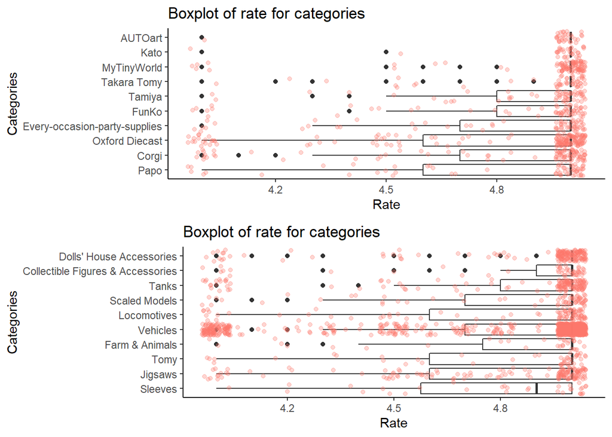

```r
data_predict<-amazon_product%>%
  group_by(cat_final)%>%
  summarize(count=n(),average_review_rating=mean(average_review_rating,na.rm=TRUE))
data_predict<-filter(data_predict,count>=30,!is.na(cat_final))
data_predict<-arrange(data_predict,desc(average_review_rating))
data_predict<-head(data_predict,10)
data_predict<-arrange(filter(amazon_product,cat_final %in% as.vector(data_predict$cat_final)),desc(average_review_rating))
pre2<-ggplot(filter(data_predict,average_review_rating>3.5),aes(x=reorder(cat_final,average_review_rating,FUN = mean),y=average_review_rating))+
  geom_boxplot()+
  geom_point(position="jitter",alpha=0.3,col="#FC766A")+
  ggtitle("Boxplot of rate for categories")+
  xlab("Categories")+
  ylab("Rate")+
  coord_flip()+
  theme_classic()
ggarrange(pre1,pre2,nrow=2,ncol=1)
```

The boxplot orders the mean of rate from bottom to top. I found that **AUTOart, Kato and MyTinyWorld** have most of their rates on 5 while others manufacturers have more rates below 5. So **AUTOart, Kato and MyTinyWorld** seem to have more possibility to get better reviews on each of the product because they have higher average rate, and smaller range.

The plot orders the mean of rate from bottom to top, so **Dolls’ House & Accessories, Collectible Figures & Accessories and Tanks** seem to have more possibility to get better reviews on each of the product because they have higher average rate, and smaller range on high scores.

## Part7: What’s next?

I want to do sentiment analysis but I can’t make it. This made me felt extremely nervous. I’m sorry that I didn’t finish sentiment analysis and I will try to do this later.